# Classe Prediction

Caroline

3/29/2021

## Introduction

We want to predict the classe variable based on the data from accelerometers on the belt, forearm, arm, and dumbbell of 6 participants. Specific details of the classe variable are as follows: “Six young health participants were asked to perform one set of 10 repetitions of the Unilateral Dumbbell Biceps Curl in five different fashions: exactly according to the specification (Class A), throwing the elbows to the front (Class B), lifting the dumbbell only halfway (Class C), lowering the dumbbell only halfway (Class D) and throwing the hips to the front (Class E).” (Source: http://groupware.les.inf.puc-rio.br/har).

There are two datasets: training and testing - The training dataset has 160 variables with 19,622 observations. - The testing dataset has 160 variables with 20 observations.

## Covariate Selection

To start off, we want to look solely at the training data set and choose the relevant dependent variables. The following variables were removed from the training set: - Variables which have a 90% missing data. - Non-numerical variables, which includes variables such as the user name and timestamp. - Variables that have near zero variance. These variables will not change the model output and therefore is of no use.

53 predictor variables are left to be used to predict the classe variable.

## Cross Validation

The validation set approach is derived from the training dataset after covariate selection, where 75% of the data is used for training, and 25% of the data is used to test the model.

To improve the accuracy estimate for the classication tree model, a 10-fold cross validation method was used.

## Predictions using Models

Three different models are used to try to predict the classe variable: 1) classification tree 2) random forest trees 3) generalized boosting model

We look at the accuracy results of each to determine which model is best for prediction.

# Classification Tree

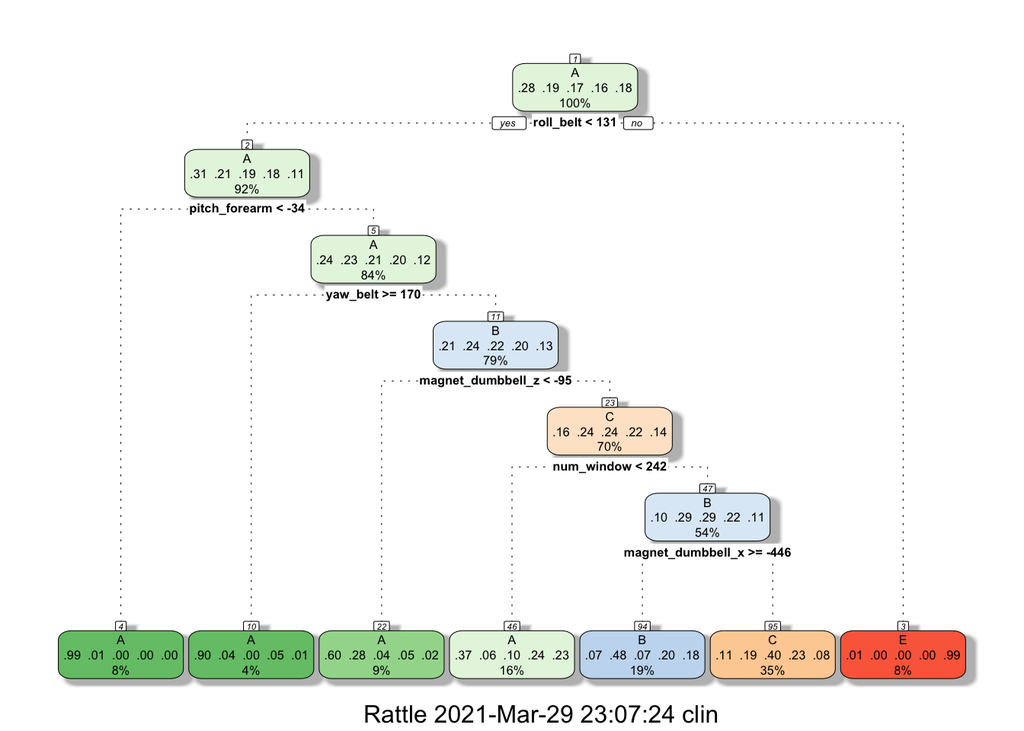

```r
modFit_rpart
```

```
## CART
##
## 14718 samples
##    53 predictor
##     5 classes: 'A', 'B', 'C', 'D', 'E'
##
## No pre-processing
## Resampling: Cross-Validated (10 fold)
## Summary of sample sizes: 13248, 13245, 13247, 13245, 13246, 13247, ...
## Resampling results across tuning parameters:
##
##   cp         Accuracy   Kappa
##   0.0322795  0.5607370  0.44093527
##   0.0505459  0.4996768  0.34532414
##   0.1162062  0.3236916  0.06005338
##
## Accuracy was used to select the optimal model using the largest value.
## The final value used for the model was cp = 0.0322795.
```

```r
confusionMatrix(pred_rpart, as.factor(test$classe))
```

```
## Confusion Matrix and Statistics
##
##           Reference
## Prediction    A    B    C    D    E
##          A 1132  193   97  219  198
##          B   66  453   67  184  163
##          C  193  303  691  401  143
##          D    0    0    0    0    0
##          E    4    0    0    0  397
##
## Overall Statistics
##
##                Accuracy : 0.5451
##                  95% CI : (0.531, 0.5591)
##     No Information Rate : 0.2845
##     P-Value [Acc > NIR] : < 2.2e-16
##
##                   Kappa : 0.4167
##
##  Mcnemar's Test P-Value : NA
##
## Statistics by Class:
##
##                      Class: A Class: B Class: C Class: D Class: E
## Sensitivity            0.8115  0.47734   0.8082   0.0000  0.44062
## Specificity            0.7985  0.87863   0.7431   1.0000  0.99900
## Pos Pred Value         0.6156  0.48553   0.3992      NaN  0.99002
## Neg Pred Value         0.9142  0.87509   0.9483   0.8361  0.88807
## Prevalence             0.2845  0.19352   0.1743   0.1639  0.18373
## Detection Rate         0.2308  0.09237   0.1409   0.0000  0.08095
## Detection Prevalence   0.3750  0.19025   0.3530   0.0000  0.08177
## Balanced Accuracy      0.8050  0.67799   0.7757   0.5000  0.71981
```

# Random forest trees

```
##
## Call:
##  randomForest(formula = as.factor(classe) ~ ., data = train, method = "rf",      prox = TRUE)
##                Type of random forest: classification
##                      Number of trees: 500
## No. of variables tried at each split: 7
##
##         OOB estimate of  error rate: 0.23%
## Confusion matrix:
##      A    B    C    D    E class.error
## A 4185    0    0    0    0 0.000000000
## B    4 2843    1    0    0 0.001755618
## C    0    6 2560    1    0 0.002726919
## D    0    0   15 2396    1 0.006633499
## E    0    0    0    6 2700 0.002217295
```

```r
confusionMatrix(pred_rf, as.factor(test$classe))
```

```
## Confusion Matrix and Statistics
##
##           Reference
## Prediction    A    B    C    D    E
##          A 1395    3    0    0    0
##          B    0  946    6    0    0
##          C    0    0  849    3    0
##          D    0    0    0  801    1
##          E    0    0    0    0  900
##
## Overall Statistics
##
##                Accuracy : 0.9973
##                  95% CI : (0.9955, 0.9986)
##     No Information Rate : 0.2845
##     P-Value [Acc > NIR] : < 2.2e-16
##
##                   Kappa : 0.9966
##
##  Mcnemar's Test P-Value : NA
##
## Statistics by Class:
##
##                      Class: A Class: B Class: C Class: D Class: E
## Sensitivity            1.0000   0.9968   0.9930   0.9963   0.9989
## Specificity            0.9991   0.9985   0.9993   0.9998   1.0000
## Pos Pred Value         0.9979   0.9937   0.9965   0.9988   1.0000
## Neg Pred Value         1.0000   0.9992   0.9985   0.9993   0.9998
## Prevalence             0.2845   0.1935   0.1743   0.1639   0.1837
## Detection Rate         0.2845   0.1929   0.1731   0.1633   0.1835
## Detection Prevalence   0.2851   0.1941   0.1737   0.1635   0.1835
## Balanced Accuracy      0.9996   0.9977   0.9961   0.9980   0.9994
```

# Generalized Boosting model

```
## Confusion Matrix and Statistics
##
##           Reference
## Prediction    A    B    C    D    E
##          A 1390   10    0    0    0
##          B    4  934    4    6    1
##          C    0    3  847   10    1
##          D    1    2    3  788   10
##          E    0    0    1    0  889
##
## Overall Statistics
##
##                Accuracy : 0.9886
##                  95% CI : (0.9852, 0.9914)
##     No Information Rate : 0.2845
##     P-Value [Acc > NIR] : < 2.2e-16
##
##                   Kappa : 0.9856
##
##  Mcnemar's Test P-Value : NA
##
## Statistics by Class:
##
##                      Class: A Class: B Class: C Class: D Class: E
## Sensitivity            0.9964   0.9842   0.9906   0.9801   0.9867
## Specificity            0.9972   0.9962   0.9965   0.9961   0.9998
## Pos Pred Value         0.9929   0.9842   0.9837   0.9801   0.9989
## Neg Pred Value         0.9986   0.9962   0.9980   0.9961   0.9970
## Prevalence             0.2845   0.1935   0.1743   0.1639   0.1837
## Detection Rate         0.2834   0.1905   0.1727   0.1607   0.1813
## Detection Prevalence   0.2855   0.1935   0.1756   0.1639   0.1815
## Balanced Accuracy      0.9968   0.9902   0.9936   0.9881   0.9932
```

# Conclusion and Results